# ePGD-ABA (2020-21) | Finance Elective | Professor Vineet Virmani | Portfolio VaR Assignment

Name:Arimitra Maiti, Email:aba20arimitram@iima.ac.in, Student ID : 6820017

5/5/2021

### Finding portfolio VaR using ARMA-GARCH

The data used in this assignment has been obtained from [**nseindia**](https://www1.nseindia.com/products/content/equities/equities/eq_security.htm) This work deeply acknowledges the knowledge sharing from Professor **Vineet** **Virmani**, Ms. **Venus** **Rais** and Mr. **Sathish** **LM**.

### Please click on each tab to check company wise results

#### WIPRO trends

##### The daily closing prices and returns look like this:

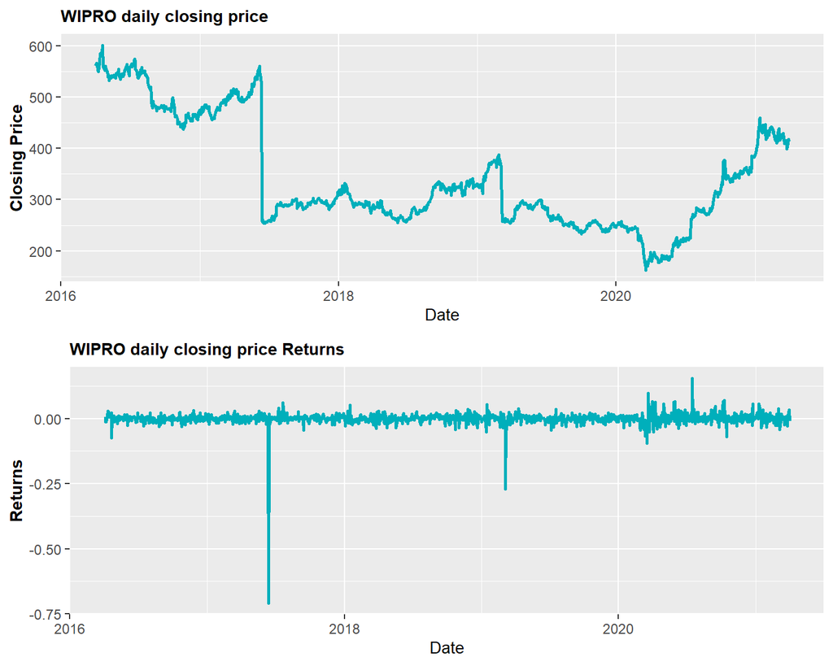

##### The weekly closing prices and returns look like this:

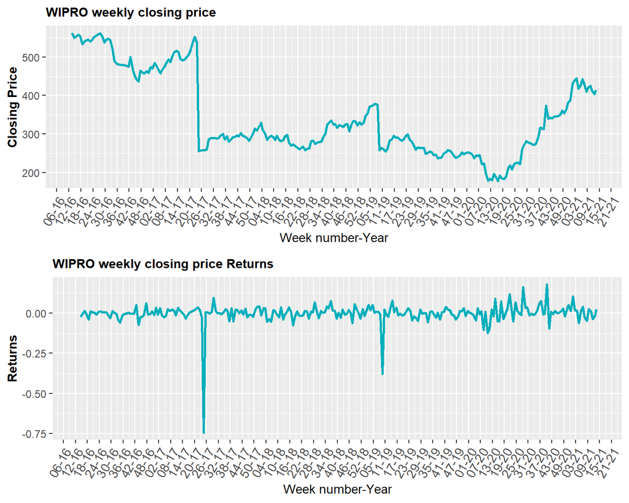

##### The monthly closing prices and returns look like this:

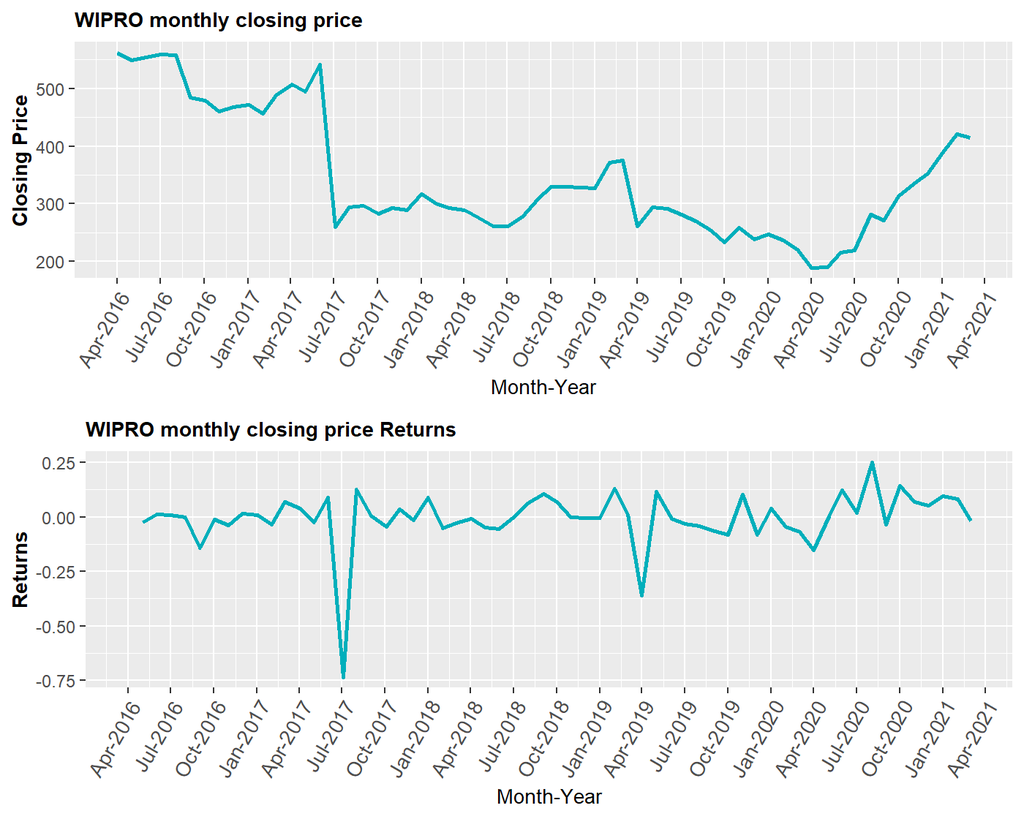

#### WIPRO daily returns model

##### The **Box-Jenkins** process for daily returns look like this:

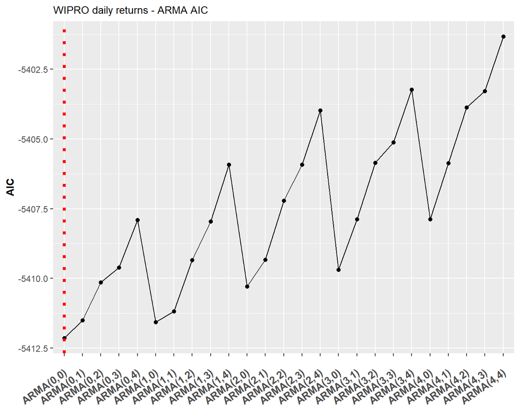

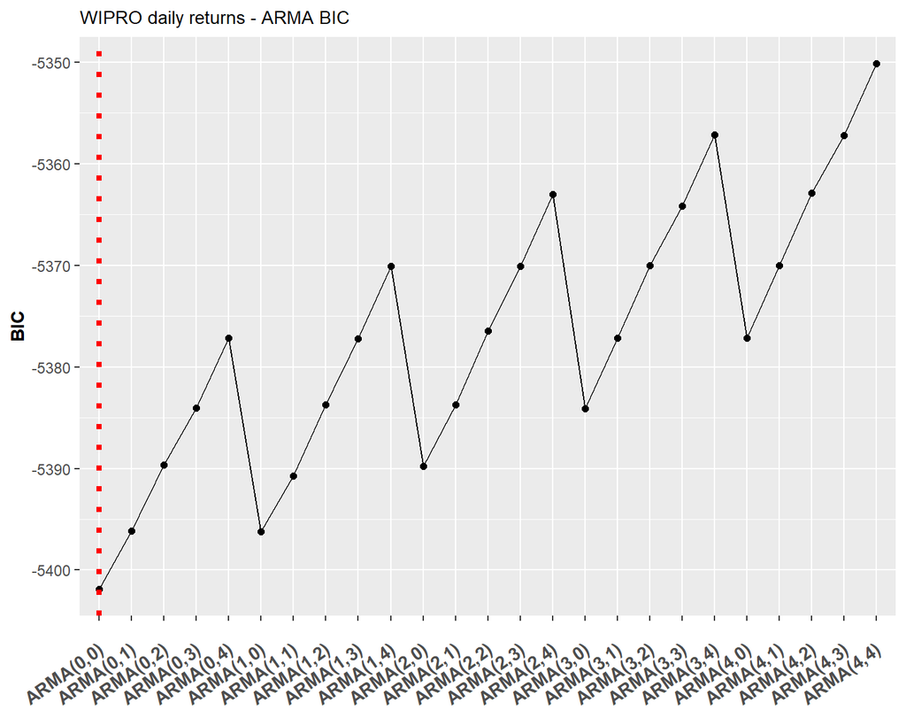

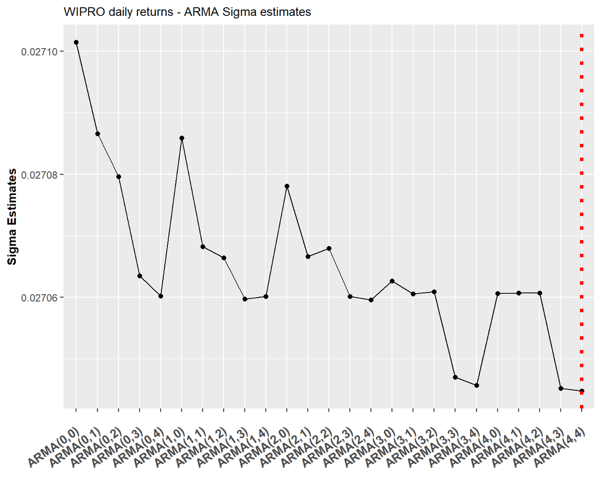

##### The best ARMA model for Wipro **daily** returns is **ARMA(0,0)**.

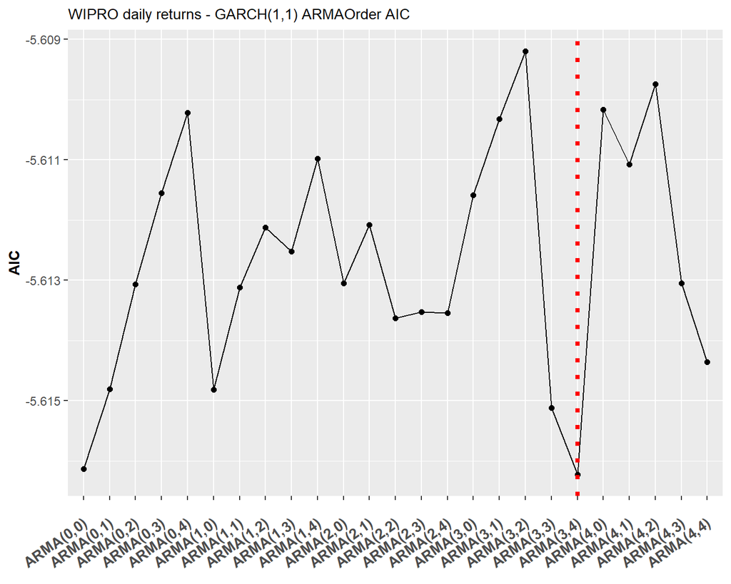

##### The best GARCH model for Wipro **daily** returns is **SGARCH(1,1),ARMA(3,4)**.

##### **Wipro** **daily** VaR summary:

- Wipro daily VaR is **-0.0267** at **alpha=5%**
- Wipro daily conditional mean is **-2^{-4}**
- Wipro daily conditional sd is **0.0161**

#### WIPRO weekly returns model

##### The **Box-Jenkins** process for weekly returns look like this:

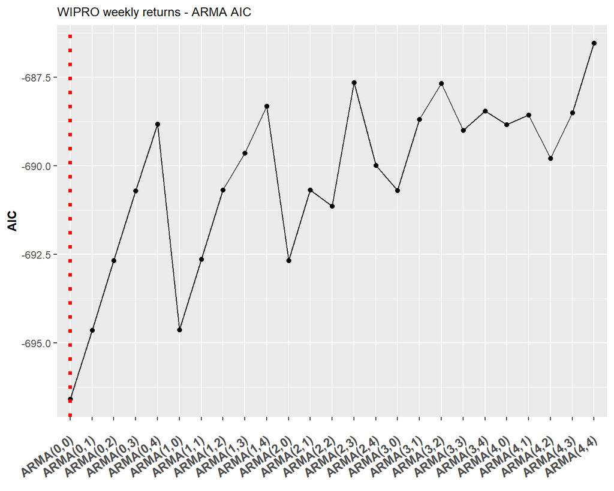

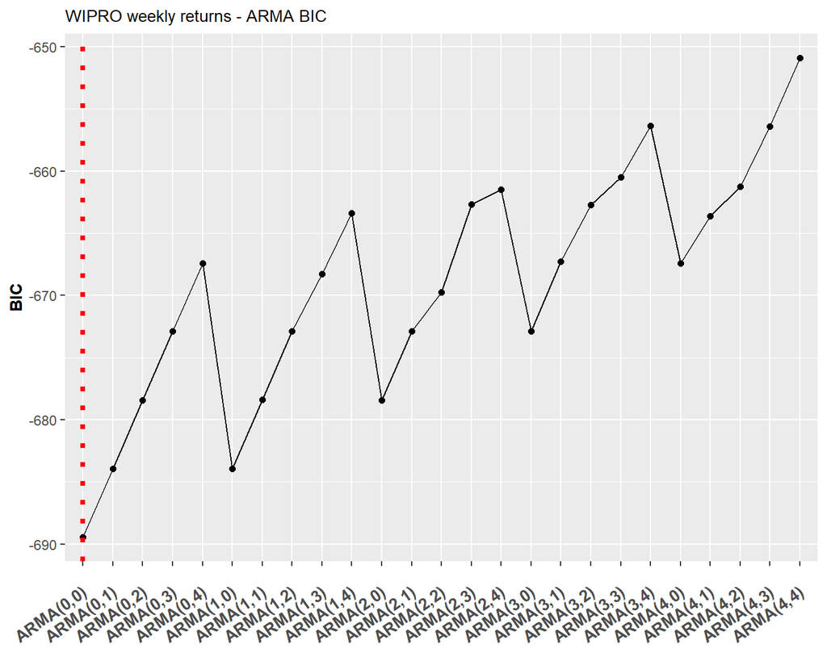

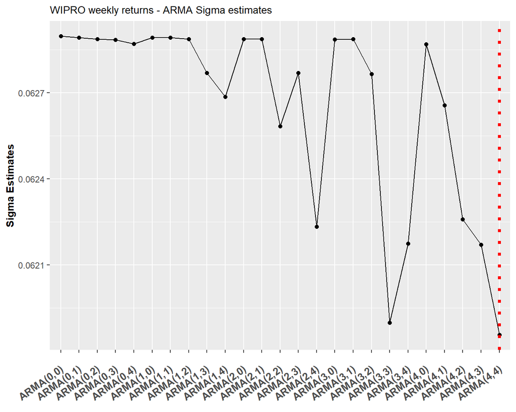

##### The best ARMA model for Wipro **weekly** returns is **ARMA(0,0)**.

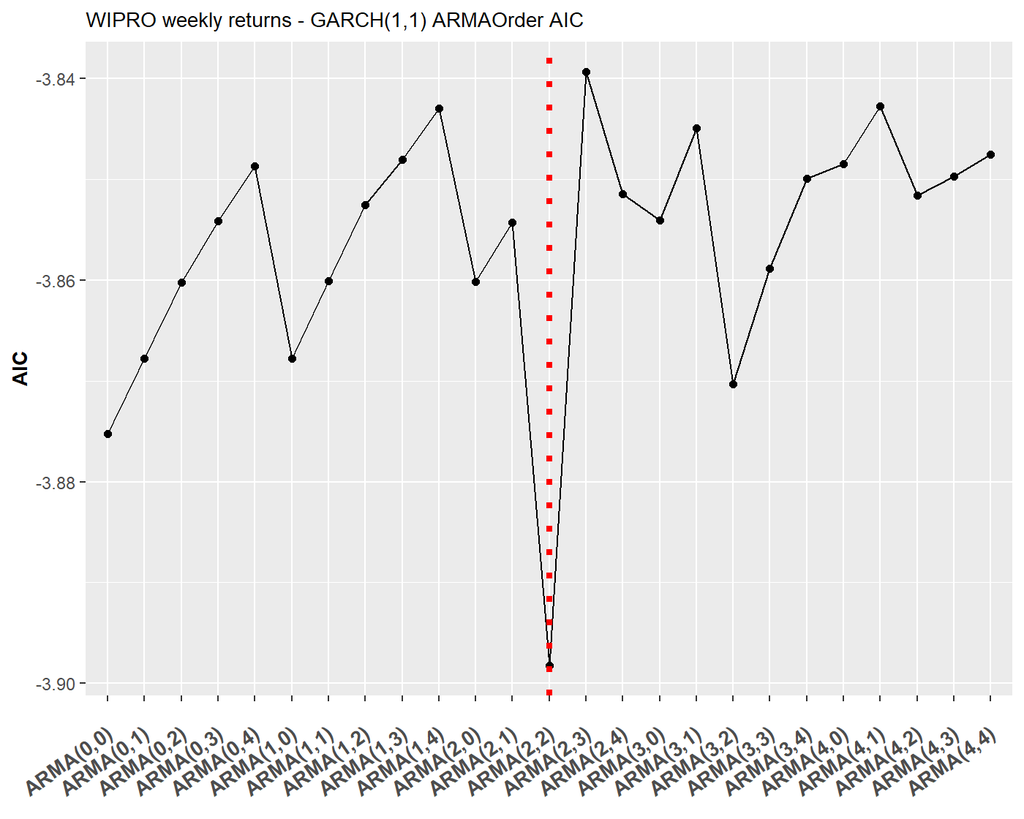

##### The best GARCH model for Wipro **weekly** returns is **SGARCH(1,1),ARMA(2,2)**.

##### **Wipro** **weekly** VaR summary:

- Wipro weekly VaR is **-0.1874** at **alpha=5%**
- Wipro weekly conditional mean is **-0.0012**
- Wipro weekly conditional sd is **0.1132**

#### WIPRO monthly returns model

##### The **Box-Jenkins** process for monthly returns look like this:

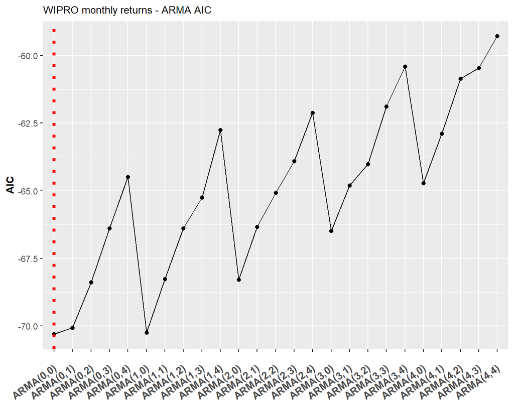

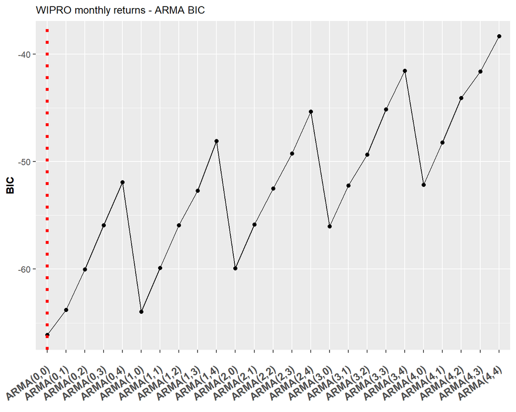

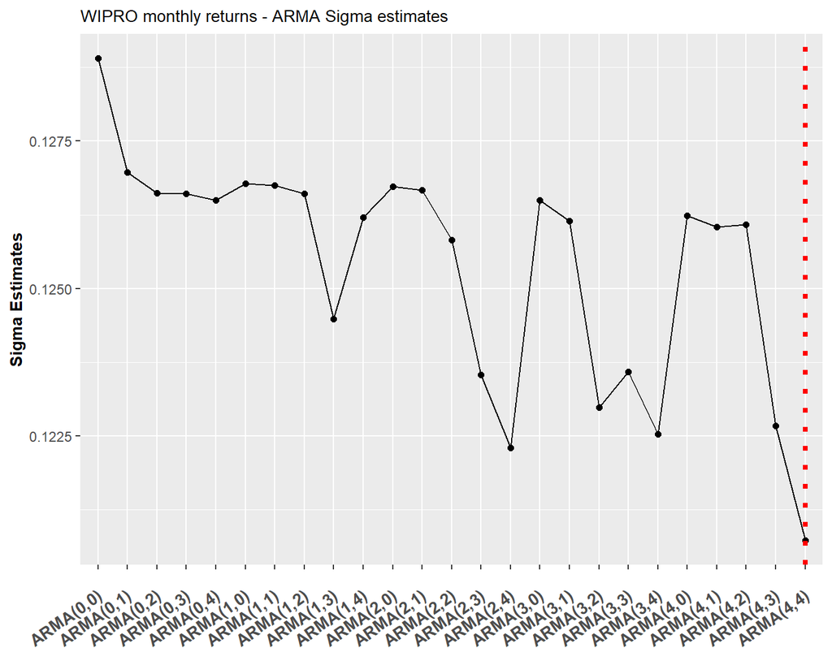

##### The best ARMA model for Wipro **monthly** returns is **ARMA(0,0)**.

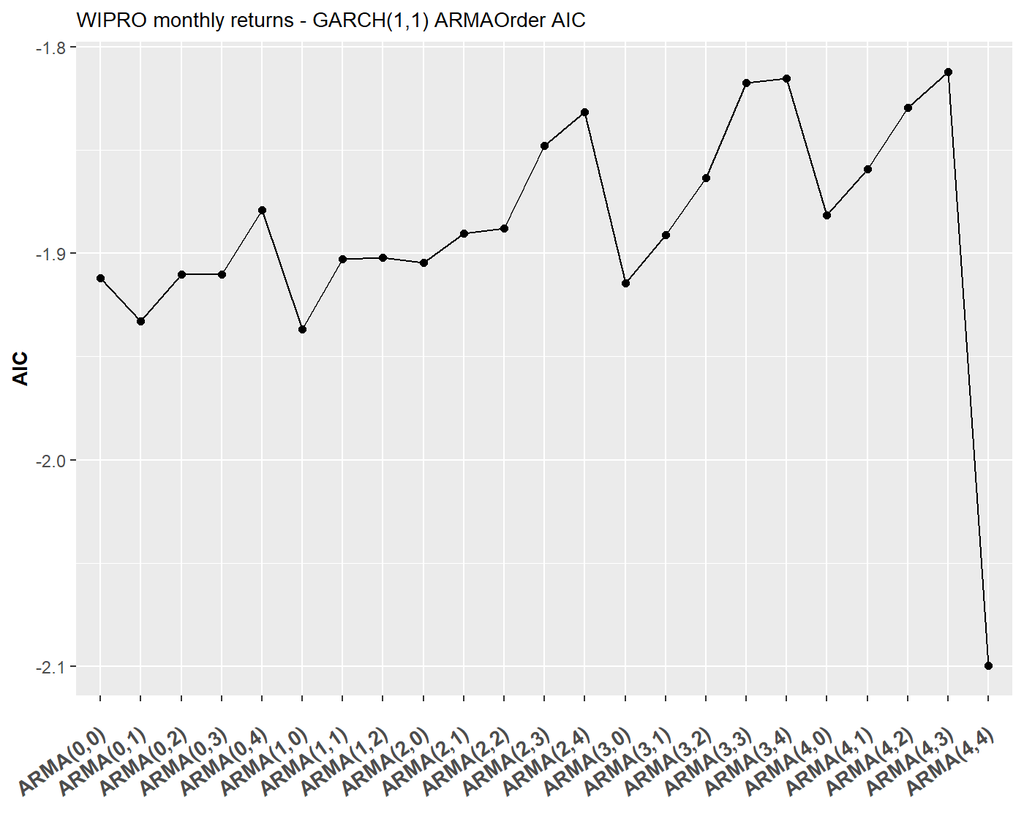

##### The best GARCH model for Wipro **monthly** returns is **SGARCH(1,1),ARMA(4,4)**.

##### **Wipro** **monthly** VaR summary:

- Wipro monthly VaR is **-0.3106** at **alpha=5%**
- Wipro monthly conditional mean is **-0.0052**
- Wipro monthly conditional sd is **0.1857**

#### TCS trends

##### The daily closing prices and returns look like this:

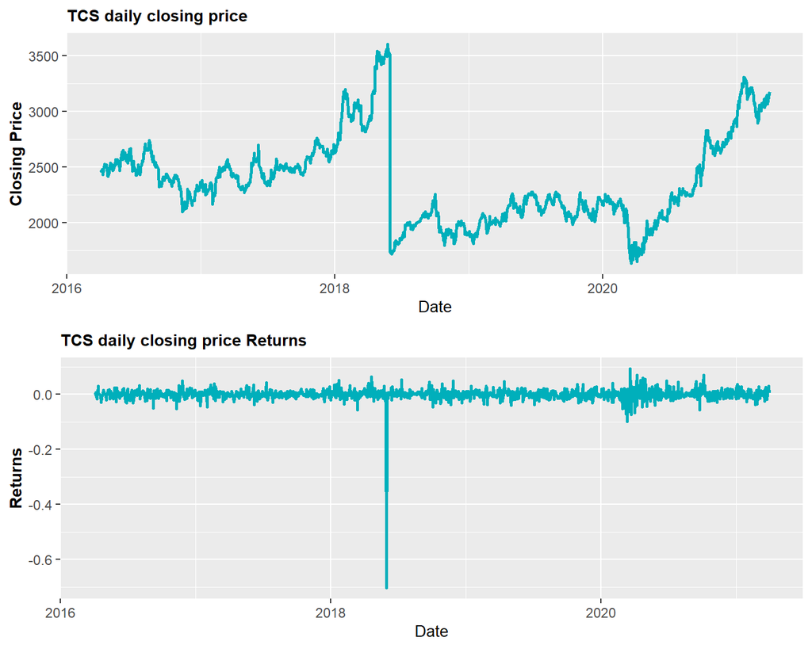

##### The weekly closing prices and returns look like this:

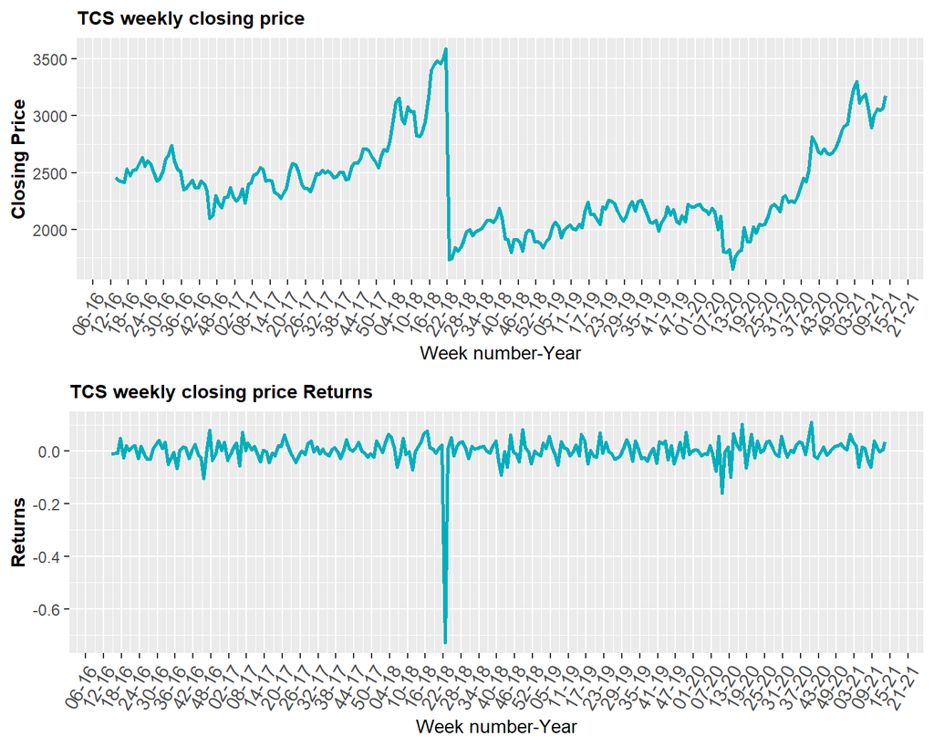

##### The monthly closing prices and returns look like this:

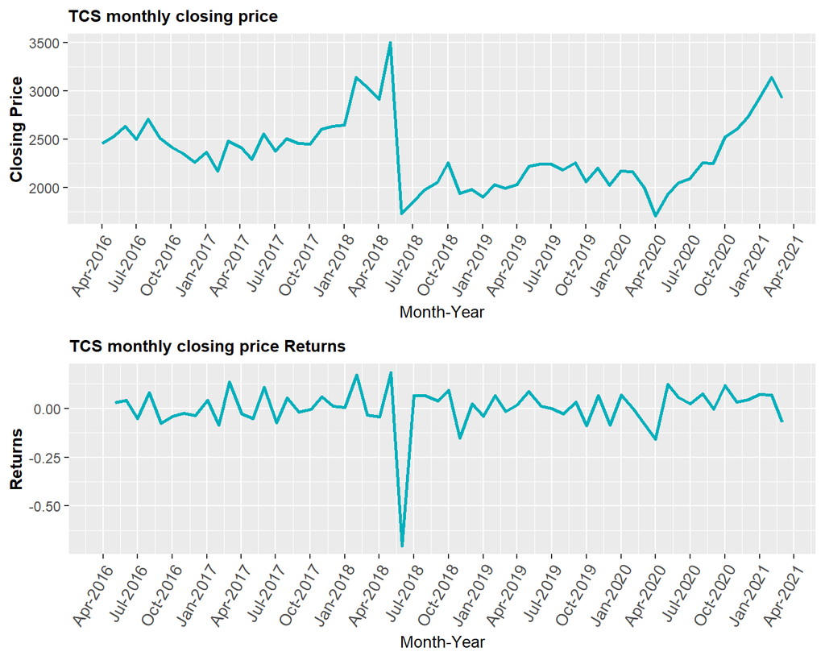

#### TCS daily returns model

##### The **Box-Jenkins** process for daily returns look like this:

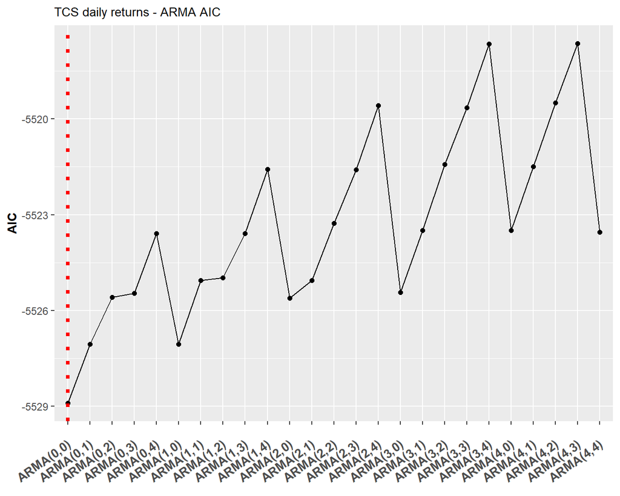

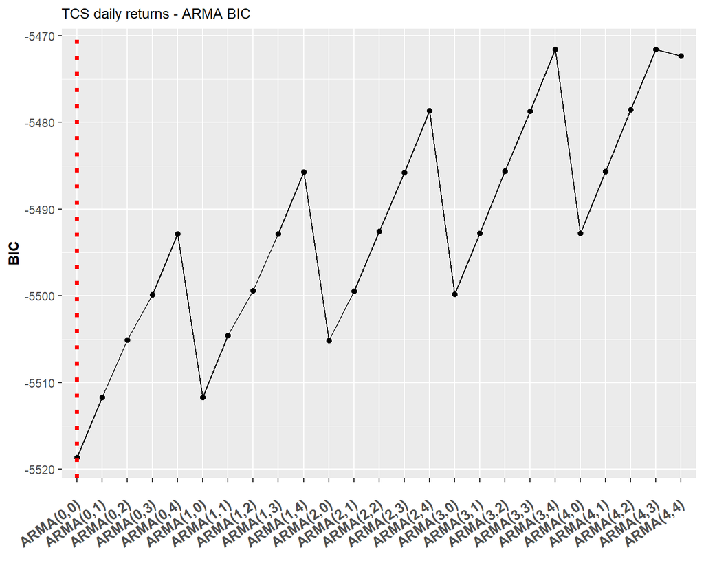

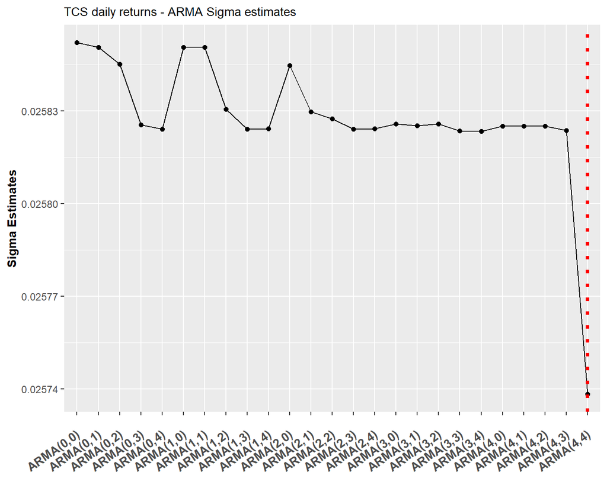

##### The best ARMA model for TCS **daily** returns is **ARMA(0,0)**.

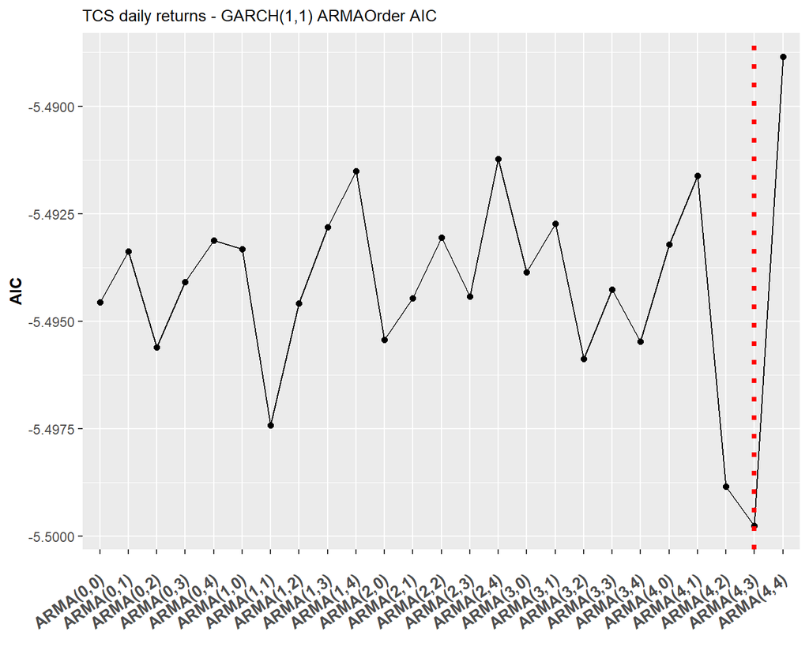

##### The best GARCH model for TCS **daily** returns is **SGARCH(1,1),ARMA(4,3)**.

##### **TCS** **daily** VaR summary:

- TCS daily VaR is **-0.0243** at **alpha=5%**
- TCS daily conditional mean is **2^{-4}**
- TCS daily conditional sd is **0.0149**

#### TCS weekly returns model

##### The **Box-Jenkins** process for weekly returns look like this:

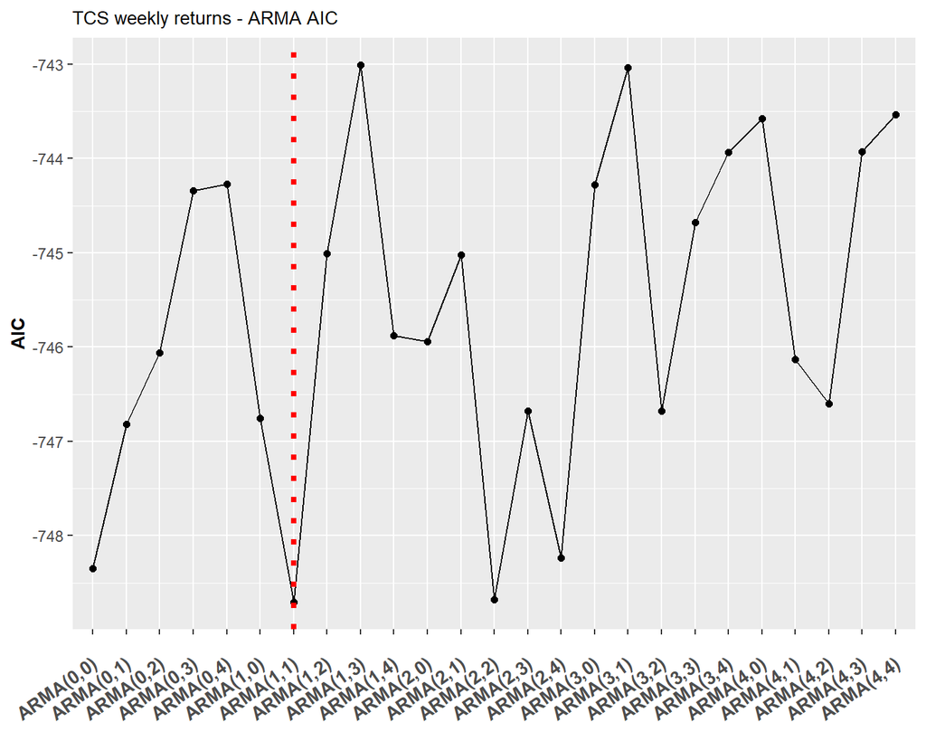

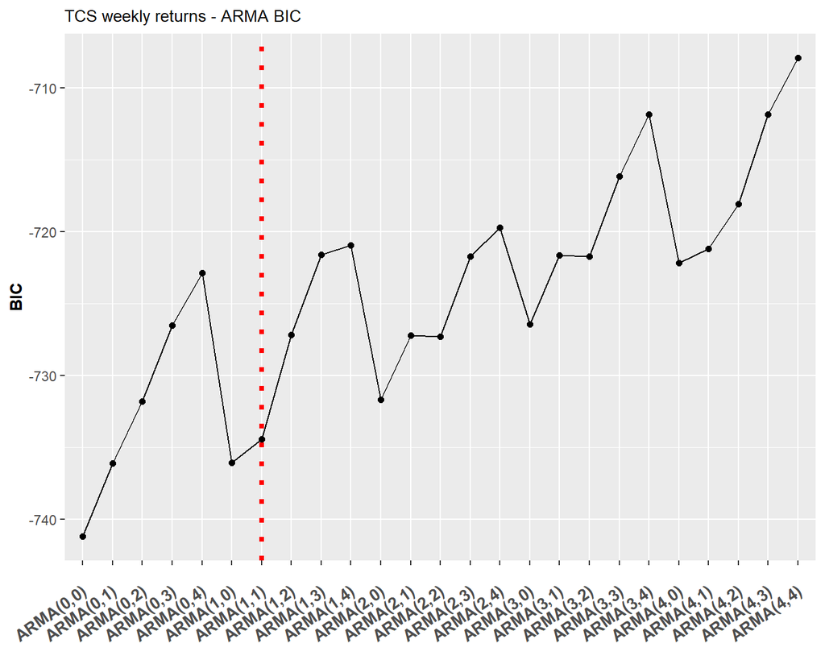

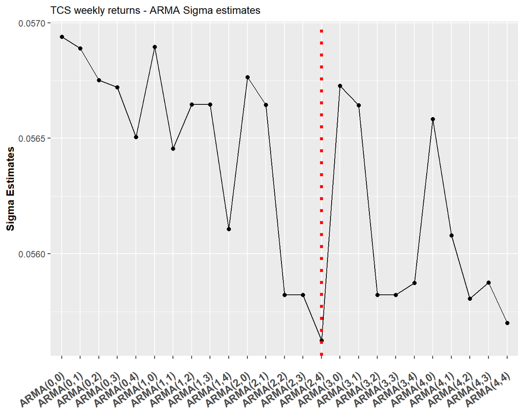

##### The best ARMA model for TCS **weekly** returns is **ARMA(1,1)**.

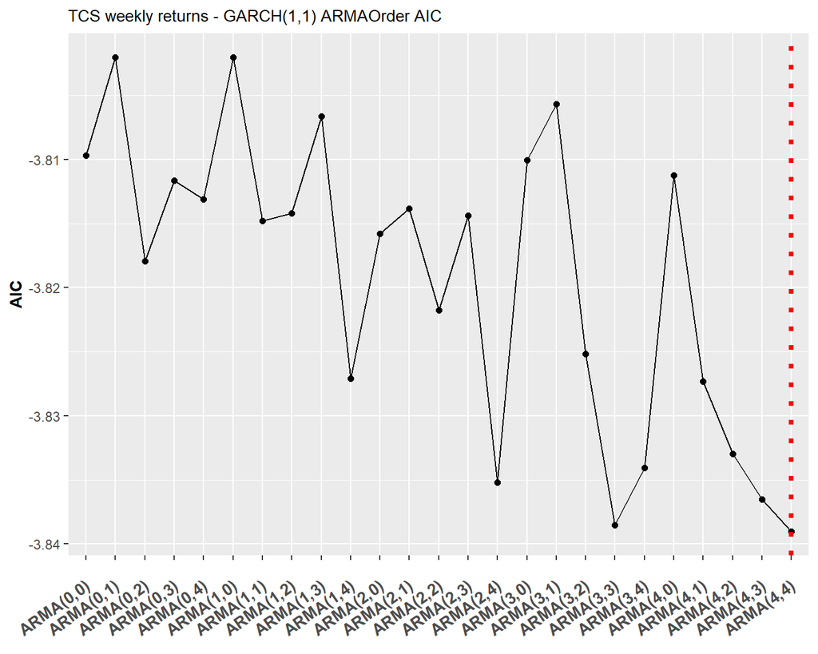

##### The best GARCH model for TCS **weekly** returns is **SGARCH(1,1),ARMA(4,4)**.

##### **TCS** **weekly** VaR summary:

- TCS weekly VaR is **-0.0759** at **alpha=5%**
- TCS weekly conditional mean is **5^{-4}**
- TCS weekly conditional sd is **0.0464**

#### TCS monthly returns model

##### The **Box-Jenkins** process for monthly returns look like this:

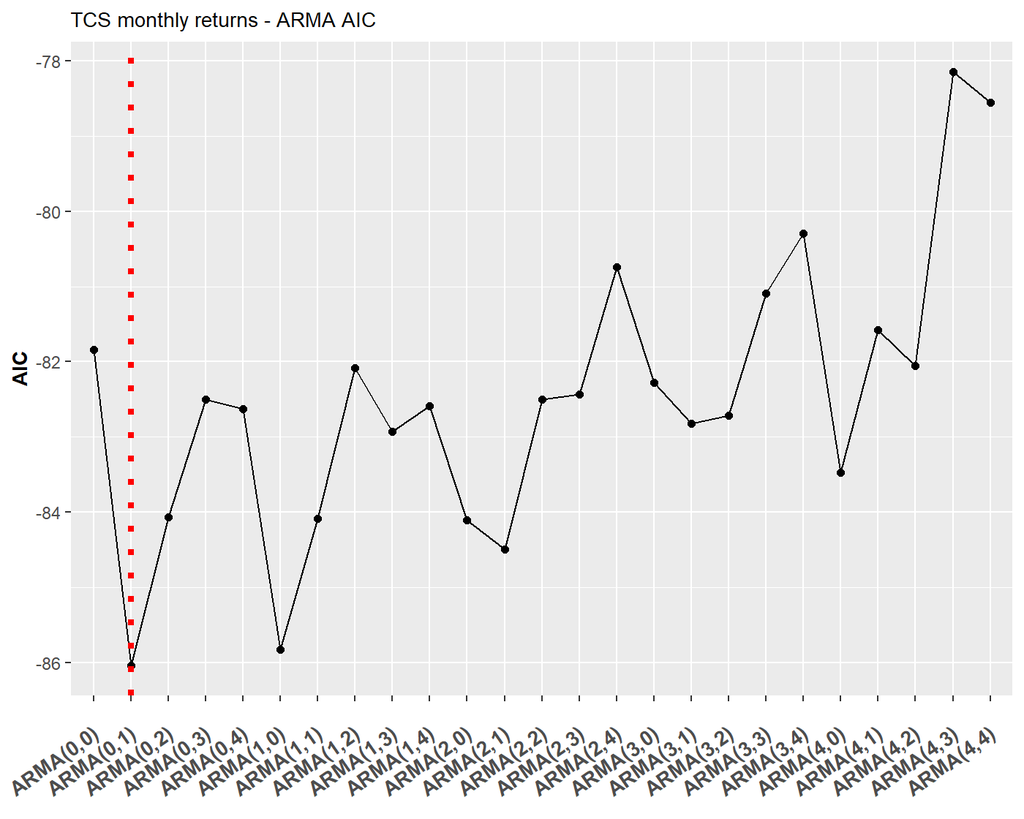

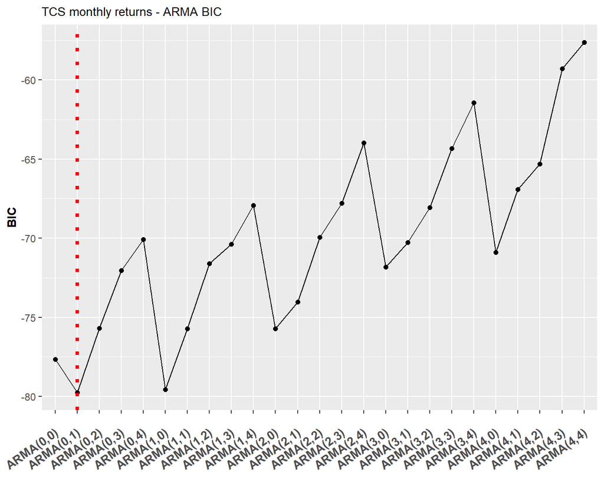

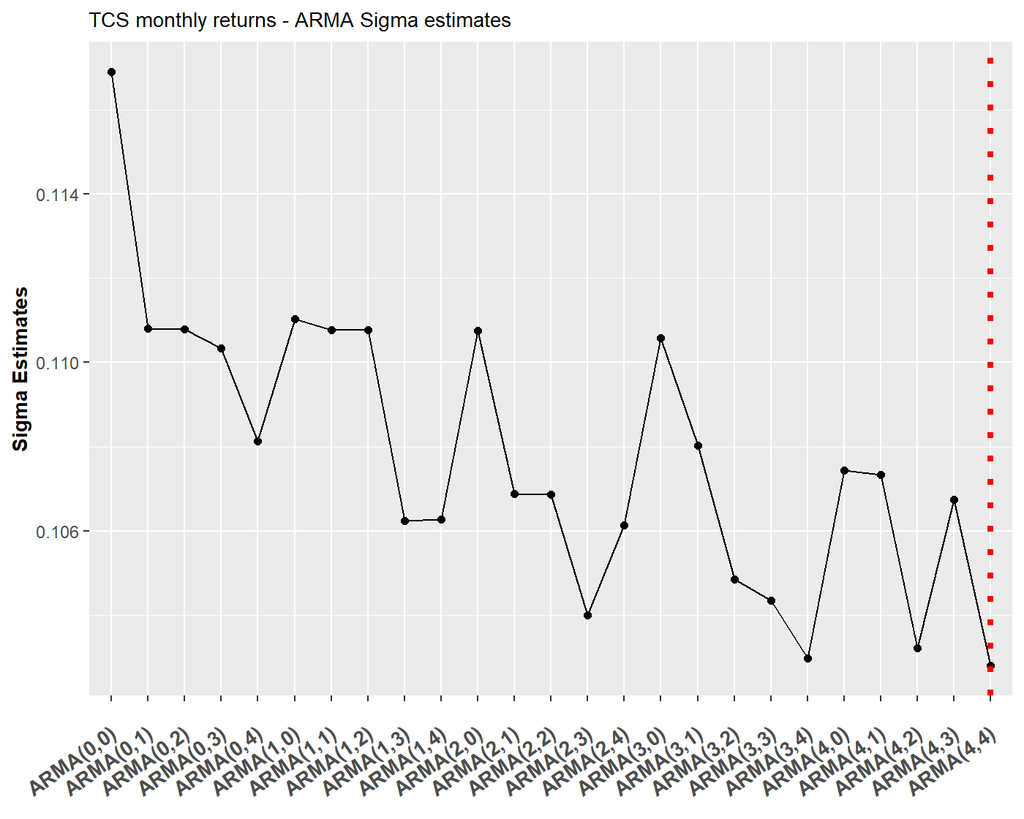

##### The best ARMA model for TCS **monthly** returns is **ARMA(0,1)**.

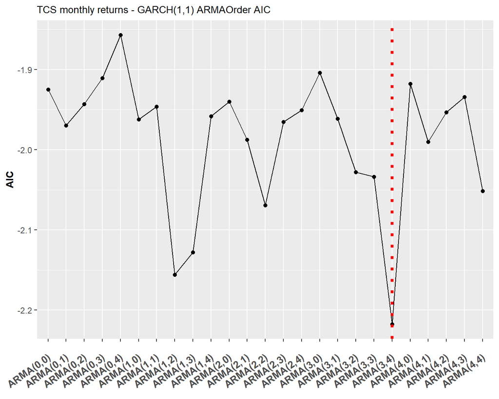

##### The best GARCH model for TCS **monthly** returns is **SGARCH(1,1),ARMA(3,4)**.

##### **TCS** **monthly** VaR summary:

- TCS monthly VaR is **-0.0438** at **alpha=5%**
- TCS monthly conditional mean is **0.003**
- TCS monthly conditional sd is **0.0284**

#### HCLTECH trends

##### The daily closing prices and returns look like this:

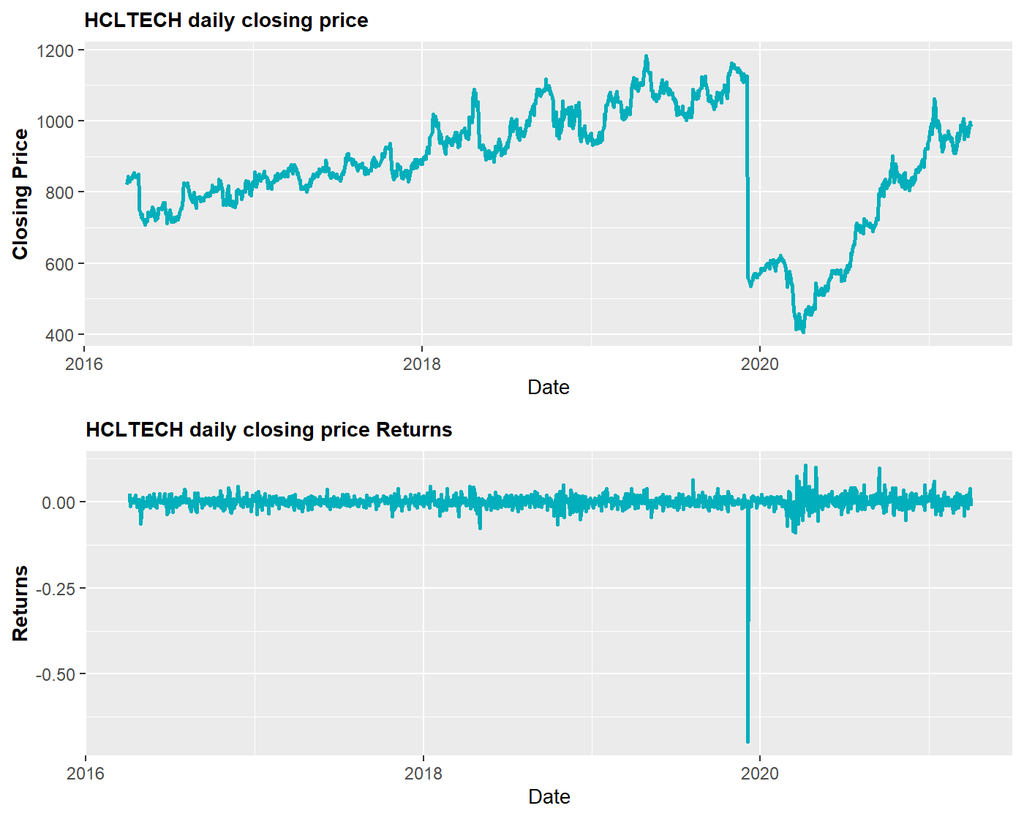